# DifferentialGeneExpressionAnalysis

Mehdi Merbah

[output not shown]

[output not shown]

## RSEM

The problem with using raw read counts is that the origin of some reads cannot always be uniquely determined. If two or more distinct transcripts in a particular sample share some common sequence (for example, if they are alternatively spliced mRNAs or mRNAs derived from paralogous genes), then sequence alignment may not be sufficient to discriminate the true origin of reads mapping to these transcripts. One approach to addressing this issue involves discarding these multiple-mapped reads (multireads for short) entirely. Another involves partitioning and distributing portions of a multiread’s expression value between all of the transcripts to which it maps. So-called “rescue” methods implement this second approach in a naive fashion. RSEM improves upon this approach, utilizing an Expectation-Maximization (EM) algorithm to estimate maximum likelihood expression levels. These “expected counts” can then be provided as a matrix (rows = mRNAs, columns = samples) to programs such as EBSeq, DESeq, or edgeR to identify differentially expressed genes. https://biowize.wordpress.com/2014/03/04/understanding-rsem-raw-read-counts-vs-expected-counts/

## DESeq2 with RSEM Estimates Matrix

The typical procedure is to import the RSEM output that includes information about the different gene isoforms obtained from multiple transcripts using the protocol described in the DESeq2 documentation for dealing with gene-level count estimates. The protocol uses the ‘tximport’ package and takes care of pre-processing the data for import into a DESeq2 object, which can then be used to do the DEA. The issue here is that we only have the gene-level count estimates matrix with no additional information, so we do not have the entirety of RSEM output. This issue was raised before and the advised solution was to typically round the count estimates to integer values and then construct the DESeq2 object from the count matrix and run the downstream analysis as usual.

### Threads for RSEM estimates Data-import

https://support.bioconductor.org/p/94003/#94028 https://www.biostars.org/p/320594/ https://support.bioconductor.org/p/94003/#94028

## Data import and Wrangling

```r
setwd('/home/mehdimerbah/R Projects/RNASeqDA/data')
disease_raw_data <- read.table("CGGA_mRNAseq_325_RSEM_genes.txt",head=T,row.names = 1)
disease_raw_data[1:5, 1:5]
```

```
##          CGGA_1001 CGGA_1006 CGGA_1007 CGGA_1011 CGGA_1015
## A1BG         12.64      7.03     30.09      6.64      1.83
## A1BG-AS1      2.12      1.13      6.64      4.32      1.39
## A2M         452.92    106.54    206.70    707.17    824.32
## A2M-AS1       3.30      0.13      0.63      1.61      1.34
## A2ML1         0.04      0.33      4.96      1.59      0.00
```

```r
setwd('/home/mehdimerbah/R Projects/RNASeqDA/data')
metadata <- read.table("CGGA_mRNAseq_325_clinical.txt", sep ="\t", head=T,row.names = 1)
meta <- metadata[order(row.names(metadata)),]
raw <- disease_raw_data[,order(colnames(disease_raw_data))]
NAs <- rownames(meta[is.na(meta$Grade),])
meta <- meta[!rownames(meta)%in%NAs, ]
raw <- raw[ ,!colnames(raw)%in%NAs]
meta$Grade <- as.factor(meta$Grade)
rounded <- round(raw)
rounded[1:10,1:5]
```

```
##          CGGA_1001 CGGA_1004 CGGA_1005 CGGA_1006 CGGA_1007
## A1BG            13        21         8         7        30
## A1BG-AS1         2         2         3         1         7
## A2M            453       277        68       107       207
## A2M-AS1          3         1         0         0         1
## A2ML1            0         1         4         0         5
## A2MP1            0         0         0         0         0
## A3GALT2          0         0         0         1         0
## A4GALT           4         4         2         3         7
## A4GNT            0         0         0         1         0
## AAAS            28        29        25        24        26
```

## EDA

### Distribution of the Grades

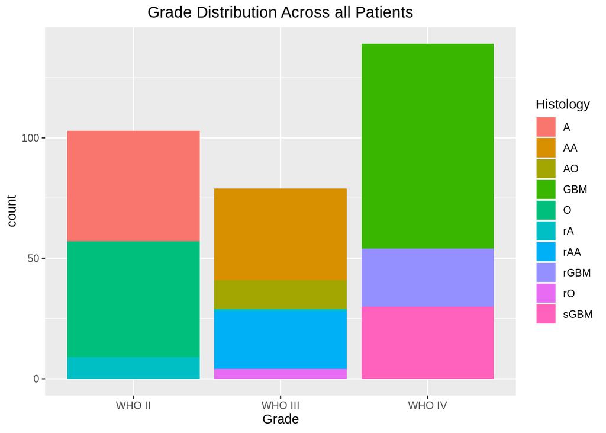

```r
#png("grade_distribution.png")
theme_update(plot.title = element_text(hjust = 0.5))
ggplot(meta, aes(x= Grade, fill=Histology)) + geom_bar() +ggtitle("Grade Distribution Across all Patients")
```

### PCA

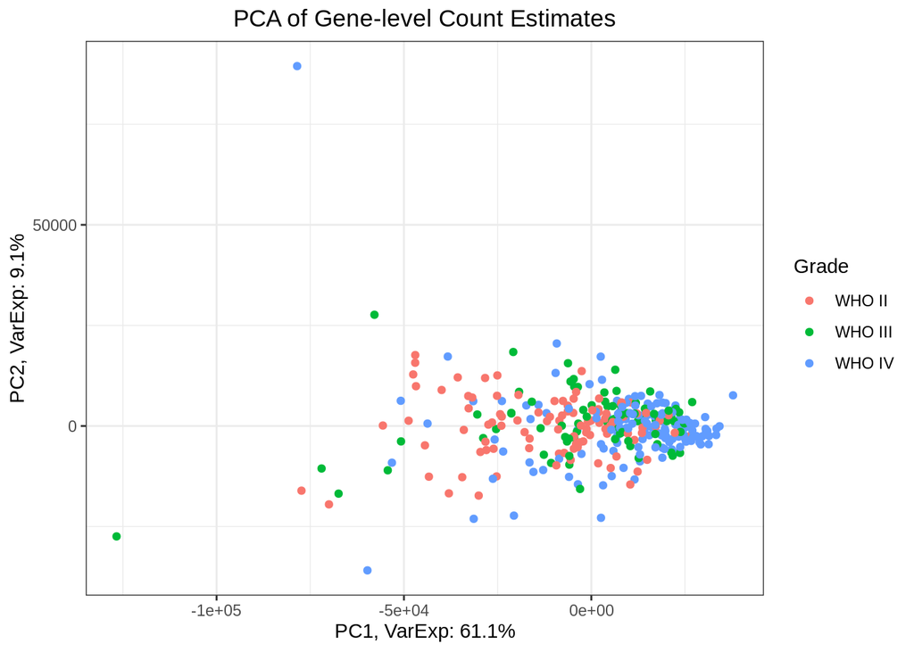

```r
pca <- prcomp(t(rounded))

percentVar <- round(100*pca$sdev^2/sum(pca$sdev^2),1)

sd_ratio <- sqrt(percentVar[2] / percentVar[1])

pca_data <- data.frame(Sample = rownames(pca$x), PC1 = pca$x[,1], PC2 = pca$x[,2], Grade = meta$Grade)

ggplot(pca_data, aes(x = PC1, y = PC2, label = Sample))+ geom_point(aes(colour = Grade)) + #geom_text()+
  ggtitle("PCA of Gene-level Count Estimates") +
  xlab(paste0("PC1, VarExp: ", percentVar[1], "%")) +
  ylab(paste0("PC2, VarExp: ", percentVar[2], "%")) +
  theme_bw() + theme(plot.title = element_text(hjust = 0.5))
```

## Differantial Expression Analysis

```r
dds <- DESeqDataSetFromMatrix(countData = rounded, colData = meta, design = ~ Grade)
```

[output not shown]

```r
res <- DESeq(dds)
```

[output not shown]

[output not shown]

[output not shown]

[output not shown]

```
## -- replacing outliers and refitting for 534 genes
## -- DESeq argument 'minReplicatesForReplace' = 7
## -- original counts are preserved in counts(dds)
```

[output not shown]

[output not shown]

```r
expRes_4v2 <- results(res)
head(expRes_4v2[order(expRes_4v2$padj),], 10)
```

```
## log2 fold change (MLE): Grade WHO.IV vs WHO.II
## Wald test p-value: Grade WHO.IV vs WHO.II
## DataFrame with 10 rows and 6 columns
##            baseMean log2FoldChange     lfcSE      stat      pvalue        padj
##           <numeric>      <numeric> <numeric> <numeric>   <numeric>   <numeric>
## TIMP1     419.13034        4.51390 0.2543976   17.7435 1.93583e-70 4.11653e-66
## ALDH5A1    20.46041       -1.56108 0.0926748  -16.8448 1.14637e-63 1.21888e-59
## COL1A2    108.34726        3.93948 0.2393097   16.4618 6.89628e-61 4.88832e-57
## GLUD1     140.23541       -1.53151 0.0935634  -16.3687 3.20014e-60 1.70127e-56
## COL6A2     69.82074        3.53397 0.2164736   16.3252 6.53468e-60 2.77920e-56
## CRY2       18.17199       -1.39783 0.0857925  -16.2932 1.10313e-59 3.90969e-56
## SERPINH1   55.88977        2.57997 0.1611367   16.0111 1.06954e-57 3.24912e-54
## WDFY3-AS2   6.10986       -1.64079 0.1031799  -15.9022 6.11949e-57 1.62664e-53
## IGFBP2    221.58926        3.51387 0.2217199   15.8482 1.44588e-56 3.41630e-53
## H19        58.72693        5.89746 0.3733887   15.7944 3.39845e-56 7.22681e-53
```

```r
write.csv(as.data.frame(expRes_4v2[order(expRes_4v2$padj),]), file="DEGs_4v2.csv")
```

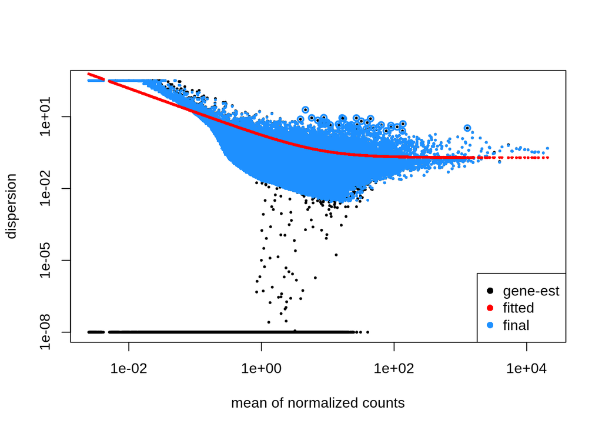

```r
DESeq2::plotDispEsts(res)
```

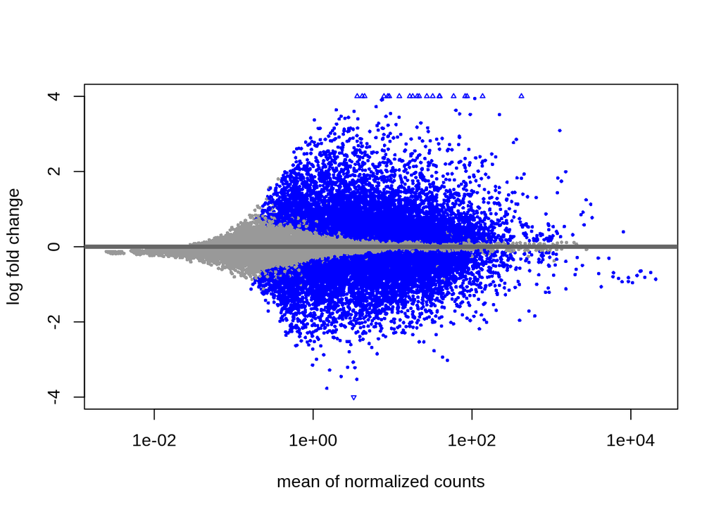

```r
plotMA(expRes_4v2, ylim=c(-4,4))
```

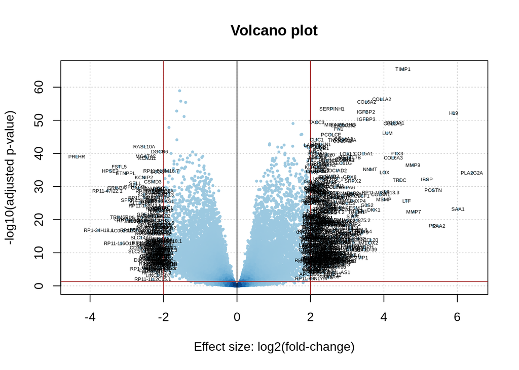

```r
log2FoldChange<- expRes_4v2$log2FoldChange
padj<- expRes_4v2$padj
pvalue<- expRes_4v2$pvalue
alpha <- 0.05 # Threshold on the adjusted p-value
cols <- densCols(log2FoldChange, -log10(padj))
plot(log2FoldChange, -log10(padj), col=cols, panel.first=grid(),
     main="Volcano plot", xlab="Effect size: log2(fold-change)", ylab="-log10(adjusted p-value)",
     pch=20, cex=0.6)
abline(v=0)
abline(v=c(-2,2), col="brown")
abline(h=-log10(alpha), col="brown")

filtered <- abs(log2FoldChange) > 2 & padj < alpha
text(log2FoldChange[filtered],
     -log10(padj)[filtered],
     lab=rownames(res)[filtered], cex=0.4)
```

## Functional Annotation with enrichR

```r
## Filtering Expression results Grades: 4 vs 2
filtered_4v2 <- subset(expRes_4v2, padj<0.05 & abs(log2FoldChange)>1)
gene_list_4v2 <- rownames(filtered_4v2)


## Extracting Expression results Grades: 4 vs 3
expRes_4v3 <- results(res, contrast = c("Grade","WHO.IV", "WHO.III"))
#head(expRes_4v3[order(expRes_4v3$padj),], 10)
write.csv(as.data.frame(expRes_4v3[order(expRes_4v3$padj),]), file="DEGs_4v3.csv")
filtered_4v3 <- subset(expRes_4v3, expRes_4v3$padj<0.05 & abs(expRes_4v3$log2FoldChange)>1)
gene_list_4v3 <- rownames(filtered_4v3)

## Extracting Expression results Grades: 3 vs 2
expRes_3v2 <- results(res, contrast = c("Grade","WHO III", "WHO II"))
#head(expRes_3v2[order(expRes_3v2$padj),], 10)
write.csv(as.data.frame(expRes_3v2[order(expRes_3v2$padj),]), file="DEGs_3v2.csv")
filtered_3v2 <- subset(expRes_3v2, expRes_3v2$padj<0.05 & abs(expRes_3v2$log2FoldChange)>1)
gene_list_3v2 <- rownames(filtered_3v2)

# Geneset enrichment with enrichR
dbs <- c("GO_Biological_Process_2018", "Reactome_2016", "KEGG_2019_Human", "RNA-Seq_Disease_Gene_and_Drug_Signatures_from_GEO", "TF_Perturbations_Followed_by_Expression")
enriched_4v2 <- enrichr(gene_list_4v2, "GO_Biological_Process_2018")
```

```
## Uploading data to Enrichr... Done.
##   Querying GO_Biological_Process_2018... Done.
## Parsing results... Done.
```

```r
enriched_4v3 <- enrichr(gene_list_4v3, "GO_Biological_Process_2018")
```

```
## Uploading data to Enrichr... Done.
##   Querying GO_Biological_Process_2018... Done.
## Parsing results... Done.
```

```r
enriched_3v2 <- enrichr(gene_list_3v2, "GO_Biological_Process_2018")
```

```
## Uploading data to Enrichr... Done.
##   Querying GO_Biological_Process_2018... Done.
## Parsing results... Done.
```

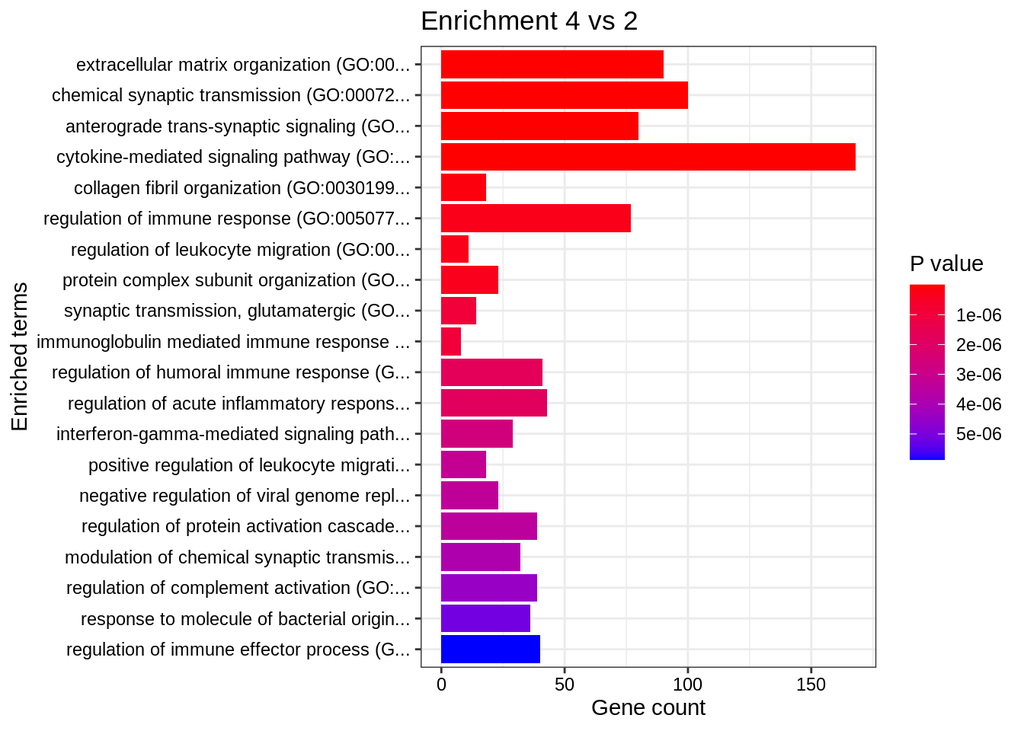

```r
plotEnrich(enriched_4v2[[1]], title= "Enrichment 4 vs 2")
```

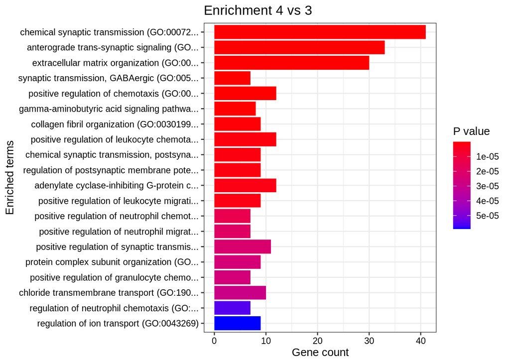

```r
plotEnrich(enriched_4v3[[1]], title= "Enrichment 4 vs 3")
```

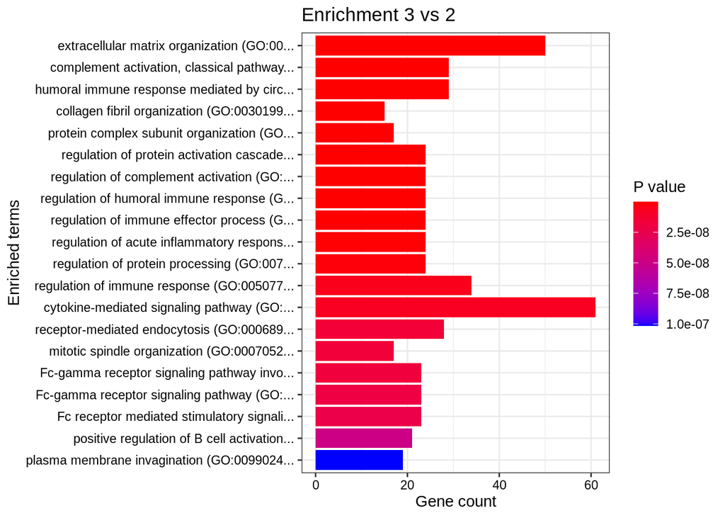

```r
plotEnrich(enriched_3v2[[1]], title= "Enrichment 3 vs 2")
```

### Number of Diff Expressed Genes

```r
length(gene_list_3v2)
```

```
## [1] 879
```

```r
length(gene_list_4v3)
```

```
## [1] 712
```

```r
length(gene_list_4v2)
```

```
## [1] 3526
```

```r
intersect(intersect(gene_list_3v2, gene_list_4v2), gene_list_4v3)
```

```
##   [1] "ABCC3"         "ABCC8"         "AC006126.4"    "AC062021.1"
##   [5] "AC132217.4"    "AC147651.4"    "ACBD7"         "ADAM12"
##   [9] "ADAMTS14"      "ANGPTL4"       "ANXA2"         "BCL2A1"
##  [13] "C15orf48"      "C1QL3"         "C6orf141"      "CA9"
##  [17] "CALN1"         "CD163"         "CHI3L1"        "CHRNA9"
##  [21] "CLCF1"         "CLEC5A"        "COL13A1"       "COL1A1"
##  [25] "COL1A2"        "COL3A1"        "COL5A1"        "COL5A2"
##  [29] "COL6A2"        "COL6A3"        "COL8A1"        "CTB-1I21.1"
##  [33] "CTD-2380F24.1" "CXCL1"         "DDN"           "DKK1"
##  [37] "DLGAP1-AS4"    "EMILIN1"       "ETNPPL"        "F2RL2"
##  [41] "F5"            "FAM196B"       "FAM19A1"       "FAM20A"
##  [45] "FER1L4"        "FMOD"          "FN1"           "FOSL1"
##  [49] "FOXD2-AS1"     "FRMPD4"        "FSTL5"         "G0S2"
##  [53] "GABRA1"        "GABRB2"        "GABRG1"        "GDF15"
##  [57] "GPX8"          "GRIN3A"        "H19"           "HMGCLL1"
```

[output cut: 27 more lines]

## DEA Without 761

Removing the CGGA_761 sample and restructuring the Datasets

```r
rounded_No761 <- rounded[, !(names(rounded) %in% "CGGA_761")]
dim(rounded_No761)
```

```
## [1] 24326   320
```

```r
dim(rounded)
```

```
## [1] 24326   321
```

```r
meta_No761 <- meta[!(names(rounded) %in% "CGGA_761"), ]
dim(meta_No761)
```

```
## [1] 320  12
```

```r
dim(meta)
```

```
## [1] 321  12
```

Now we can run the Diff Expression analysis on the new Datasets

```r
dds_No761 <- DESeqDataSetFromMatrix(countData = rounded_No761, colData = meta_No761, design = ~ Grade)
```

[output not shown]

```r
res_No761 <- DESeq(dds_No761)
```

[output not shown]

[output not shown]

[output not shown]

[output not shown]

```
## -- replacing outliers and refitting for 534 genes
## -- DESeq argument 'minReplicatesForReplace' = 7
## -- original counts are preserved in counts(dds)
```

[output not shown]

[output not shown]

```r
expRes_No761<- results(res_No761)
head(expRes_No761[order(expRes_No761$padj),], 10)
```

```
## log2 fold change (MLE): Grade WHO.IV vs WHO.II
## Wald test p-value: Grade WHO.IV vs WHO.II
## DataFrame with 10 rows and 6 columns
##            baseMean log2FoldChange     lfcSE      stat      pvalue        padj
##           <numeric>      <numeric> <numeric> <numeric>   <numeric>   <numeric>
## TIMP1     420.29200        4.52383 0.2545050   17.7750 1.10364e-70 2.34690e-66
## ALDH5A1    20.48372       -1.56234 0.0929785  -16.8032 2.31165e-63 2.45786e-59
## COL1A2    108.62411        3.94890 0.2395216   16.4866 4.57923e-61 3.24591e-57
## COL6A2     69.99068        3.54325 0.2165843   16.3597 3.70941e-60 1.97202e-56
## GLUD1     140.43154       -1.53088 0.0938492  -16.3121 8.09954e-60 3.44473e-56
## CRY2       18.19159       -1.39860 0.0860724  -16.2491 2.26572e-59 8.03008e-56
## SERPINH1   55.92422        2.58538 0.1614805   16.0105 1.07989e-57 2.87048e-54
## WDFY3-AS2   6.10427       -1.65560 0.1033772  -16.0151 1.00176e-57 2.87048e-54
## IGFBP2    221.76638        3.52037 0.2222465   15.8399 1.64966e-56 3.89777e-53
## H19        58.91391        5.90787 0.3735425   15.8158 2.42149e-56 5.14931e-53
```

```r
filtered_No761 <- subset(expRes_No761, expRes_No761$padj<0.05 & abs(expRes_No761$log2FoldChange)>1)
dim(filtered_No761)
```

```
## [1] 3547    6
```

```r
gene_list_No761 <- rownames(filtered_No761)
```

```r
length(gene_list_4v2)
```

```
## [1] 3526
```

```r
length(gene_list_No761)
```

```
## [1] 3547
```

```r
# The following should find the conjunction of the two gene_list sets
length(intersect(gene_list_4v2, gene_list_No761))
```

```
## [1] 3516
```

```r
# check which genes are not common
list_uncommon <- setdiff(union(gene_list_4v2, gene_list_No761), intersect(gene_list_4v2, gene_list_No761))
```

There does not seem to be a great difference between the results with and without the CGGA_761 sample

Plotting the results

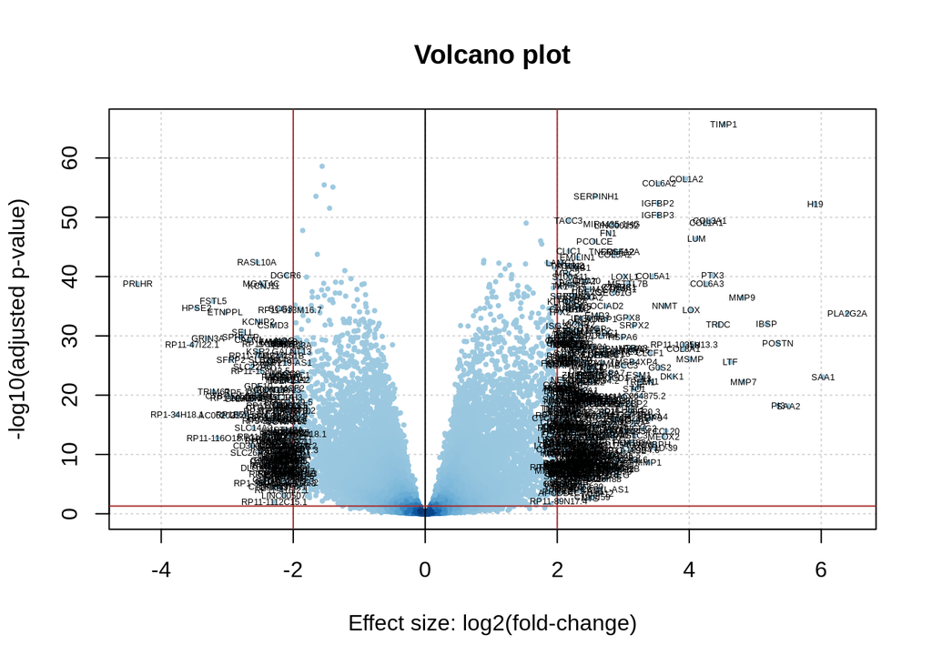

```r
cols <- densCols(expRes_No761$log2FoldChange, -log10(expRes_No761$padj))
plot(expRes_No761$log2FoldChange, -log10(expRes_No761$padj), col=cols, panel.first=grid(),
     main="Volcano plot", xlab="Effect size: log2(fold-change)", ylab="-log10(adjusted p-value)",
     pch=20, cex=0.6)
abline(v=0)
abline(v=c(-2,2), col="brown")
abline(h=-log10(alpha), col="brown")

filtered <- abs(expRes_No761$log2FoldChange) > 2 & expRes_No761$padj < alpha
text(expRes_No761$log2FoldChange[filtered],
     -log10(expRes_No761$padj)[filtered],
     lab=rownames(res_No761)[filtered], cex=0.4)
```